# Building a K-means Model Workflow

1. Introduction
2. Step 1: Imports
3. Step 2: Data Exploration
4. Step 3: Data Modeling
5. Step 4:Results and Evaluation
6. Considerations

[figure not shown]

# Introduction

> - K-means clustering is very effective when segmenting data and attempting to find patterns. Because clustering is used in a broad array of industries, I created this project to demonstrate my proficiency using this model type.
> - Within this project, I am a consultant for a scientific organization that works to support and sustain penguin colonies. I have been tasked with helping other staff members learn more about penguins in order to achieve this mission.

**The purpose**: To demonstrate an active and working knowledge of unsupervised machine learning.

**The Goal**: To use a K-means clustering model to group this dataset and identify patterns that provide important insights about penguins.

# Step 1: Imports

```python
# Importing standard operational packages.
import numpy as np
import pandas as pd

# Important tools for modeling and evaluation.
from sklearn.cluster import KMeans
from sklearn.metrics import silhouette_score
from sklearn.preprocessing import StandardScaler

# Importing visualization packages.
import matplotlib.pyplot as plt
import seaborn as sns
```

```python
# Loading and saving the `pandas` DataFrame in variable `penguins`.
penguins = pd.read_csv("penguins.csv")
```

# Step 2: Data Exploration

```python
# Reviewing the first 10 rows.
penguins.head(n = 10)
```

|  | species | island | bill_length_mm | bill_depth_mm | flipper_length_mm | body_mass_g | sex |
| --- | --- | --- | --- | --- | --- | --- | --- |
| 0 | Adelie | Torgersen | 39.1 | 18.7 | 181.0 | 3750.0 | male |
| 1 | Adelie | Torgersen | 39.5 | 17.4 | 186.0 | 3800.0 | female |
| 2 | Adelie | Torgersen | 40.3 | 18.0 | 195.0 | 3250.0 | female |
| 3 | Adelie | Torgersen | NaN | NaN | NaN | NaN | NaN |
| 4 | Adelie | Torgersen | 36.7 | 19.3 | 193.0 | 3450.0 | female |
| 5 | Adelie | Torgersen | 39.3 | 20.6 | 190.0 | 3650.0 | male |
| 6 | Adelie | Torgersen | 38.9 | 17.8 | 181.0 | 3625.0 | female |
| 7 | Adelie | Torgersen | 39.2 | 19.6 | 195.0 | 4675.0 | male |
| 8 | Adelie | Torgersen | 34.1 | 18.1 | 193.0 | 3475.0 | NaN |
| 9 | Adelie | Torgersen | 42.0 | 20.2 | 190.0 | 4250.0 | NaN |

### Exploring the dataset

```python
# Finding out how many penguin types there are.
penguins['species'].unique()
```

```
array(['Adelie', 'Chinstrap', 'Gentoo'], dtype=object)
```

```python
# Finding the count of each species type.
penguins['species'].value_counts(dropna = False)
```

```
species
Adelie       152
Gentoo       124
Chinstrap     68
Name: count, dtype: int64
```

**Observations**:

> - There are three types of species. The Chinstrap species is less common than the other species. This has a chance to affect K-means clustering as K-means performs best with similar sized groupings.
> - For purposes of clustering, I'll pretend I don't know that there are three different types of species. Then, I'll explore whether the algorithm can discover the different species. I may even find other relationships within this dataset.

### Checking for missing values

> - An assumption of K-means is that there are no missing values. I'll check for missing values within the rows of this dataset.

```python
# Checking for missing values.
penguins.isnull().sum()
```

```
species               0
island                0
bill_length_mm        2
bill_depth_mm         2
flipper_length_mm     2
body_mass_g           2
sex                  11
dtype: int64
```

```python
# Dropping rows with missing values and saving the DataFrame in variable `penguins_subset`.
penguins_subset = penguins.dropna(axis=0).reset_index(drop = True)
```

```python
# Reviewing the first 10 rows.
penguins_subset.head(10)
```

|  | species | island | bill_length_mm | bill_depth_mm | flipper_length_mm | body_mass_g | sex |
| --- | --- | --- | --- | --- | --- | --- | --- |
| 0 | Adelie | Torgersen | 39.1 | 18.7 | 181.0 | 3750.0 | male |
| 1 | Adelie | Torgersen | 39.5 | 17.4 | 186.0 | 3800.0 | female |
| 2 | Adelie | Torgersen | 40.3 | 18.0 | 195.0 | 3250.0 | female |
| 3 | Adelie | Torgersen | 36.7 | 19.3 | 193.0 | 3450.0 | female |
| 4 | Adelie | Torgersen | 39.3 | 20.6 | 190.0 | 3650.0 | male |
| 5 | Adelie | Torgersen | 38.9 | 17.8 | 181.0 | 3625.0 | female |
| 6 | Adelie | Torgersen | 39.2 | 19.6 | 195.0 | 4675.0 | male |
| 7 | Adelie | Torgersen | 41.1 | 17.6 | 182.0 | 3200.0 | female |
| 8 | Adelie | Torgersen | 38.6 | 21.2 | 191.0 | 3800.0 | male |
| 9 | Adelie | Torgersen | 34.6 | 21.1 | 198.0 | 4400.0 | male |

### Encoding the data

```python
#Capitalizing all 'Male' and 'Female' values within the 'sex' column
penguins_subset['sex'] = penguins_subset['sex'].str.upper()
```

```python
# Converting the `sex` column from categorical to numeric.
penguins_subset = pd.get_dummies(penguins_subset, drop_first = True, columns=['sex'])
```

### Dropping a column

> - I'll drop the categorical column `island` from this dataset. While it has value, this project is trying to confirm if penguins of the same species exhibit different physical characteristics based on sex. This doesn't include location.
> - Note that the `species` column is not numeric. I will not drop the `species` column for now. It could potentially be used to help understand the clusters later.

```python
# Dropping the 'island' column.
penguins_subset = penguins_subset.drop(['island'], axis=1)
```

### Scaling the features

Because K-means uses distance between observations as its measure of similarity, it's important to scale the data before modeling. I'll use a third-party tool, such as scikit-learn's `StandardScaler` function. `StandardScaler` scales each point xᵢ by subtracting the mean observed value for that feature and dividing by the standard deviation:

x-scaled = (xᵢ – mean(X)) / σ

This ensures that all variables have a mean of 0 and variance/standard deviation of 1.

**Note:** Because the species column isn't a feature, it doesn't need to be scaled.

First, I'll copy all the features except the `'species'` column to a DataFrame `X`.

```python
# Excluding the `species` variable from X
X = penguins_subset.drop(['species'], axis=1)
```

```python
#Scaling the features and assigning the scaled data to variable `X_scaled`.
X_scaled = StandardScaler().fit_transform(X)
```

# Step 3: Data Modeling

Now, I'll fit the K-means and evaluate inertia for different values of k. Because I may not know how many clusters exist in the data, I'll start by fitting K-means and examining the inertia values for different values of k. To do this, I'll write a function called `kmeans_inertia` that takes in `num_clusters` and `x_vals` (`X_scaled`) and returns a list of each k-value's inertia.

When using K-means inside the function, I'll set the `random_state` to `42`. This way, others can reproduce my results.

```python
# Fitting K-means and evaluating inertia for different values of k.
num_clusters = [i for i in range(2, 11)]

def kmeans_inertia(num_clusters, x_vals):
    """
    Accepts as arguments list of ints and data array.
    Fits a KMeans model where k = each value in the list of ints.
    Returns each k-value's inertia appended to a list.
    """
    inertia = []
    for num in num_clusters:
        kms = KMeans(n_clusters=num, random_state=42)
        kms.fit(x_vals)
        inertia.append(kms.inertia_)

    return inertia
```

### Using the `kmeans_inertia` function to return a list of interia for k=2 to 10

```python
# Returning a list of inertia for k=2 to 10.
inertia = kmeans_inertia(num_clusters, X_scaled)
inertia
```

```
[885.6224143652248,
 578.8284278107234,
 386.14534424773285,
 284.5464837898288,
 217.92858573807675,
 201.39287843423264,
 185.46131043232296,
 173.45452114979847,
 164.12001520260705]
```

Next, I'll create a line plot that shows the relationship between `num_clusters` and `inertia`.

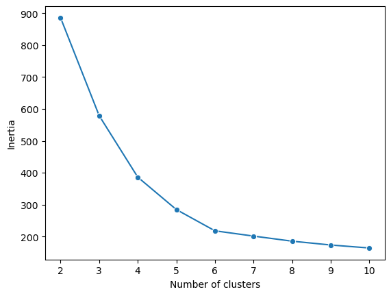

```python
# Creating a line plot.
plot = sns.lineplot(x=num_clusters, y=inertia, marker = 'o')
plot.set_xlabel("Number of clusters");
plot.set_ylabel("Inertia");
```

**Observations**:

> - The plot seems to depict an elbow at six clusters, but there isn't a clear method for confirming that a six-cluster model is optimal. Therefore, I'll check the silhouette scores.

# Step 4: Results and Evaluation

> - Now, I'll evaluate the silhouette score using the `silhouette_score()` function. Silhouette scores are used to study the distance between clusters.
> - Then, I'll compare the silhouette score of each value of k, from 2 through 10. To do this, I'll write a function called `kmeans_sil` that takes in `num_clusters` and `x_vals` (`X_scaled`) and returns a list of each k-value's silhouette score.

```python
# Evaluating silhouette score.
# Writing a function to return a list of each k-value's score.
def kmeans_sil(num_clusters, x_vals):
    """
    Accepts as arguments list of ints and data array.
    Fits a KMeans model where k = each value in the list of ints.
    Calculates a silhouette score for each k value.
    Returns each k-value's silhouette score appended to a list.
    """
    sil_score = []
    for num in num_clusters:
        kms = KMeans(n_clusters=num, random_state=42)
        kms.fit(x_vals)
        sil_score.append(silhouette_score(x_vals, kms.labels_))

    return sil_score


sil_score = kmeans_sil(num_clusters, X_scaled)
sil_score
```

```
[0.44398088353055243,
 0.45101024097188364,
 0.5080140996630784,
 0.519998574860868,
 0.5263224884981607,
 0.47774022332151733,
 0.4221920732643224,
 0.36062890821417276,
 0.3617250563420018]
```

Next, I'll create a line plot that shows the relationship between `num_clusters` and `sil_score`.

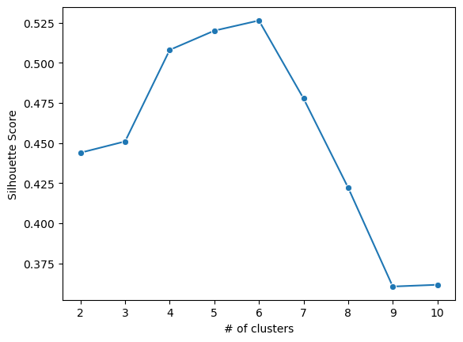

```python
# Creating a line plot.
plot = sns.lineplot(x=num_clusters, y=sil_score, marker = 'o')
plot.set_xlabel("# of clusters");
plot.set_ylabel("Silhouette Score");
```

**Observations**:

> - The graph shows Silhouette scores near 1 indicate that samples are far away from neighboring clusters. Scores close to 0 indicate that samples are on or very close to the decision boundary between two neighboring clusters.
> - The plot indicates that the silhouette score is closest to 1 when the data is partitioned into `six` clusters, although `five` clusters also yield a relatively good silhouette score.

### Choosing an optimal k-value

> - To decide on an optimal k-value, I'll fit a six-cluster model to this dataset.

```python
# Fitting a 6-cluster model.
kmeans6 = KMeans(n_clusters=6, random_state=42)
kmeans6.fit(X_scaled)
```

```
KMeans(n_clusters=6, random_state=42)
```

```python
# Printing unique labels of the fit model
print('Unique labels:', np.unique(kmeans6.labels_))
```

```
Unique labels: [0 1 2 3 4 5]
```

Now, I'll create a new column `cluster` that indicates cluster assignment in the DataFrame `penguins_subset`. It's important that I understand the meaning of each cluster's labels, then decide whether the clustering makes sense.

**Note:** I'll use the `penguins_subset` because it is often easier to interpret unscaled data.

```python
# Creating a new column `cluster`.
penguins_subset['cluster'] = kmeans6.labels_
penguins_subset.head()
```

|  | species | bill_length_mm | bill_depth_mm | flipper_length_mm | body_mass_g | sex_MALE | cluster |
| --- | --- | --- | --- | --- | --- | --- | --- |
| 0 | Adelie | 39.1 | 18.7 | 181.0 | 3750.0 | True | 2 |
| 1 | Adelie | 39.5 | 17.4 | 186.0 | 3800.0 | False | 1 |
| 2 | Adelie | 40.3 | 18.0 | 195.0 | 3250.0 | False | 1 |
| 3 | Adelie | 36.7 | 19.3 | 193.0 | 3450.0 | False | 1 |
| 4 | Adelie | 39.3 | 20.6 | 190.0 | 3650.0 | True | 2 |

```python
# Verifying if any `cluster` can be differentiated by `species`
penguins_subset.groupby(by=['cluster', 'species']).size()
```

```
cluster  species
0        Gentoo       58
1        Adelie       73
         Chinstrap     5
2        Adelie       71
3        Adelie        2
         Chinstrap    34
4        Gentoo       61
5        Chinstrap    29
dtype: int64
```

Next, I'll interpret the groupby outputs. Although the results of the groupby show that each `'cluster'` can be differentiated by `'species'`, it is useful to visualize these results. The graph shows that each `'cluster'` can be differentiated by `'species'`.

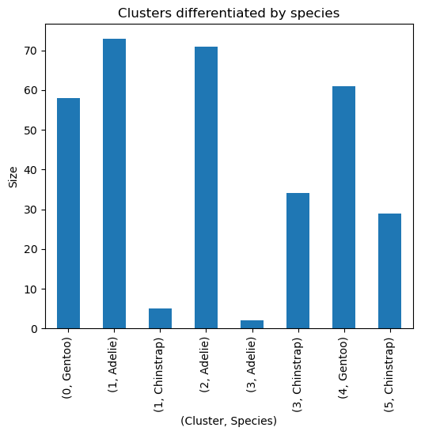

```python
penguins_subset.groupby(by=['cluster', 'species']).size().plot.bar(title='Clusters differentiated by species',
                                                                   figsize=(6, 5),
                                                                   ylabel='Size',
                                                                   xlabel='(Cluster, Species)');
```

```python
# Verifying if each `cluster` can be differentiated by `species` AND `sex_MALE`.
penguins_subset.groupby(by=['cluster','species', 'sex_MALE']).size().sort_values(ascending = False)
```

```
cluster  species    sex_MALE
1        Adelie     False       73
2        Adelie     True        71
4        Gentoo     True        61
0        Gentoo     False       58
3        Chinstrap  True        34
5        Chinstrap  False       29
1        Chinstrap  False        5
3        Adelie     True         2
dtype: int64
```

**Observations**:

> - Even though clusters 1 and 3 weren't all one species or sex, the `groupby` indicates that the algorithm produced clusters mostly differentiated by species and sex.

Finally, I'll interpret the groupby outputs and visualize these results. The graph shows that each `'cluster'` can be differentiated by `'species'` and `'sex_MALE'`. Furthermore, each cluster is mostly comprised of one sex and one species.

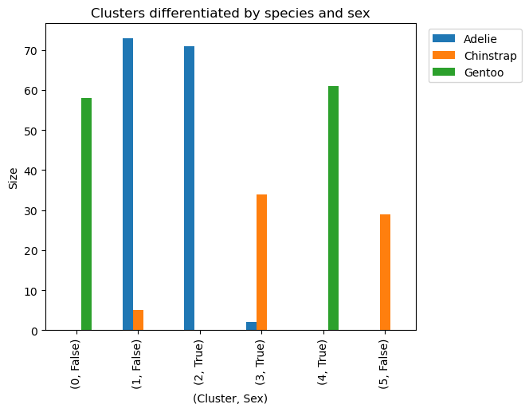

```python
penguins_subset.groupby(by=['cluster','species','sex_MALE']).size().unstack(level = 'species', fill_value=0).plot.bar(title='Clusters differentiated by species and sex',
                                                                                                                      figsize=(6, 5),
                                                                                                                      ylabel='Size',
                                                                                                                      xlabel='(Cluster, Sex)')
plt.legend(bbox_to_anchor=(1.3, 1.0))
```

# Considerations

**Takeaways**:

- Many machine learning workflows are about cleaning, encoding, and scaling data.
- Inertia and silhouette score can be used to find the optimal value of clusters.
- Clusters can find natural groupings in data.
- The clusters in this project are mostly differentiated by species and sex as shown by the groupby results and corresponding graphs.
- The elbow plot and especially the silhouette scores suggests that 6 clusters are optimal for this data.
- Having 6 clusters makes sense because the study suggests that there is sexual dimorphism (differences between the sexes) for each of the three species (2 sexes * 3 different species = 6 clusters).

**Communication to stakeholders**:

- The K-means clustering enabled this data to be effectively grouped. It helped identify patterns that can educate team members about penguins.
- The success of the cluster results suggests that the organization can apply clustering to other projects and continue augmenting employee education.